# BCB420 - Computational System Biology

Assignment #3 - Data Set Pathway and Network Analysis

Fangyi Li

April 4th, 2023

# 1. Introduction

Compilation of A3 is entirely independent of A1 and A2, so there’s no need to compile A1/A2 before compiling A3.

- Please check [A1 HTML](https://github.com/bcb420-2023/Fangyi_Li/blob/main/A1/a1.html) and [A2 HTML](https://github.com/bcb420-2023/Fangyi_Li/blob/main/A2/A2_FangyiLi.html) for details of previous plots.

## 1.1 Package Setup

The following are the packages needed for this assignment.

```r
if (!requireNamespace("BiocManager", quietly = TRUE)) {
  install.packages("BiocManager")
}
library(BiocManager)

if (!requireNamespace("GEOmetadb", quietly = TRUE)) {
  BiocManager::install("GEOmetadb")
}
library(GEOmetadb)

if (!requireNamespace("biomaRt", quietly = TRUE)) {
  BiocManager::install("biomaRt")
}
library(biomaRt)

if (!requireNamespace("edgeR", quietly = TRUE)) {
  install.packages("edgeR")
}
library(edgeR)

if (!requireNamespace("DBI", quietly = TRUE)) {
  install.packages("DBI")
}
library(DBI)

if (!requireNamespace("limma", quietly = TRUE)) {
  install.packages("limma")
}
library(limma)

if(!requireNamespace("knitr", quietly=TRUE)) {
  install.packages("knitr")
}
library(knitr)

if(!requireNamespace("kableExtra", quietly=TRUE)) {
  install.packages("kableExtra")
}
library(kableExtra)

if (!requireNamespace("ComplexHeatmap", quietly = TRUE)) {
  install.packages("ComplexHeatmap")
}
library(ComplexHeatmap)

if (!requireNamespace("circlize", quietly = TRUE)) {
  install.packages("circlize")
}
library(circlize)

if (!requireNamespace("gprofiler2", quietly = TRUE)) {
  install.packages("gprofiler2")
}
library(gprofiler2)

if (!requireNamespace("RCurl", quietly = TRUE)) {
  install.packages("RCurl")
}
library(RCurl)

if (!requireNamespace("GSA", quietly = TRUE)) {
  install.packages("GSA")
}
library(GSA)

if (!requireNamespace("VennDiagram", quietly = TRUE)) {
  install.packages("VennDiagram")
}
library(VennDiagram)
```

## 1.2 Data Set Overview

Data set **GSE89225** is selected, cleaned, and normalized in A1. Differential gene expression analysis and threshold over-representation analysis are performed in A2. The data set contains RNAseq data from normal breast parenchyma (NBP) and tumor tissues (Plitas et al. 2016). Following is a concise summary of data manipulation.

### Download and Define

```r
# Get expression data
geo_id <- "GSE89225"

# Get expression data from GEOquery
sfiles <- GEOquery::getGEOSuppFiles(geo_id)
fnames <- rownames(sfiles)

# Read CSV and change column names
tcell_exp <- read.csv(fnames[1], header = TRUE, check.names = FALSE)
colnames(tcell_exp)[1] <- "ensembl_gene_id"

# Separate by "_" and define groups
samples <- data.frame(lapply(colnames(tcell_exp)[2:35],
                             FUN=function(x){unlist(strsplit(x, split = "_"))}))
colnames(samples) <- colnames(tcell_exp)[2:35]
rownames(samples) <- c("Tcell_type","tissue_type", "patients")
samples <- data.frame(t(samples))
```

### Clean and Map

```r
# Check for duplicated genes
summarized_gene_counts <- sort(table(tcell_exp$ensembl_gene_id), decreasing = TRUE)

# Remove invalid Ensenbl gene ids
valid_tcell_exp <- tcell_exp[grep("ENSG", tcell_exp$ensembl_gene_id), ]

# Translate out counts into counts per million
cpms <- edgeR::cpm(valid_tcell_exp[, 2:35])
rownames(cpms) <- valid_tcell_exp[, 1]

# Get rid of low counts
keep <- rowSums(cpms > 1) >= 10
filtered_tcell_exp <- valid_tcell_exp[keep, ]

# Connect to the desired mart
ensembl <- biomaRt::useMart("ensembl")

# Get the set of datasets availble
datasets <- biomaRt::listDatasets(ensembl)

# Limit to the human datasets availble
ensembl <- biomaRt::useDataset("hsapiens_gene_ensembl", mart=ensembl)

# Naming id conversion stash
conversion_stash <- "tcell_id_conversion.rds"

# Save the conversion
if (file.exists(conversion_stash)) {
  tcell_id_conversion <- readRDS(conversion_stash)
} else {
  tcell_id_conversion <- biomaRt::getBM(attributes = c("ensembl_gene_id","hgnc_symbol"),
                                      filters = c("ensembl_gene_id"),
                                      values = filtered_tcell_exp$ensembl_gene_id,
                                      mart = ensembl)
  saveRDS(tcell_id_conversion, conversion_stash)
}

# Annotated version (merge)
annot_tcell_exp <- merge(tcell_id_conversion, filtered_tcell_exp, all.y = TRUE)
```

### Normalization (TMM)

Trimmed Mean of M-values (TMM) normalization is used, which is a method that calculates scaling factors for each sample to account for differences in the total number of reads across samples and to adjust for other technical biases (Isserlin 2023f).

- For more details, please check [A1 HTML](https://github.com/bcb420-2023/Fangyi_Li/blob/main/A1/a1.html).

```r
# Reassignment
original_tcell_exp <- annot_tcell_exp

# Create an edgeR container for RNASeq count data
original_data_matrix <- as.matrix(original_tcell_exp[, 3:36])
rownames(original_data_matrix) <- original_tcell_exp$ensembl_gene_id

# Calculate the normalization factors
d <- edgeR::DGEList(counts = original_data_matrix, group = samples$tissue_type)
d <- edgeR::calcNormFactors(d)

# Normalize data set
normalized_tcell_exp <- edgeR::cpm(d)
normalized_tcell_exp <- cbind(original_tcell_exp[, 1:2], normalized_tcell_exp)
rownames(normalized_tcell_exp) <- NULL

# Remove duplicate HGNC symbols to avoid false assignment in the future
normalized_tcell_exp <- dplyr::distinct(normalized_tcell_exp, hgnc_symbol, .keep_all = TRUE)
```

### Differential Gene Expression Analysis

The Quasi Likelihood (QL) model implemented in the `edgeR` package is used for differential expression analysis. The model uses an empirical Bayes shrinkage approach to estimate the gene-specific dispersions and identify differentially expressed genes (Y. Chen, Lun, and Smyth 2016).

- For more details, please check [A2 HTML](https://github.com/bcb420-2023/Fangyi_Li/blob/main/A2/A2_FangyiLi.html).

```r
# Create data matrix
expressionMatrix <- as.matrix(normalized_tcell_exp[, 3:36])
rownames(expressionMatrix) <- normalized_tcell_exp$ensembl_gene_id
colnames(expressionMatrix) <- colnames(normalized_tcell_exp)[3:36]

# Create design matrix
edgeR_model_design <- model.matrix(~ samples$tissue_type)

# Set edgeR object
edgeR_d <- edgeR::DGEList(counts = expressionMatrix,
                    group=samples$tissue_type)

# Estimate dispersion
edgeR_d <- edgeR::estimateDisp(edgeR_d, edgeR_model_design)

# Fit the Quasi liklihood model
edgeR_fit <- edgeR::glmQLFit(edgeR_d, edgeR_model_design)
edgeR_qlf <- edgeR::glmQLFTest(edgeR_fit, coef = 'samples$tissue_typetumor')

# Sort by p-values
qlf_output_hits <- edgeR::topTags(edgeR_qlf,
                                  sort.by = "PValue",
                                  n = nrow(normalized_tcell_exp))

# Clustering samples by sample type
tumor <- normalized_tcell_exp[, grepl("tumor", colnames(normalized_tcell_exp))]
NBP <- normalized_tcell_exp[, grepl("NBP", colnames(normalized_tcell_exp))]
exp_avg <- data.frame(hgnc_symbol = gsub("-", ".", normalized_tcell_exp[, 2]),
                      Tumor = rowMeans(tumor),
                      NBP = rowMeans(NBP))

# Construct the edgeR result table
qlf_result <- cbind(qlf_output_hits$table, ensembl_gene_id = rownames(qlf_output_hits$table))
qlf_result <- merge(tcell_id_conversion, qlf_result, by = "ensembl_gene_id", all.x = TRUE)
```

### Thresholded Over-representation Analysis

Gene set is separated into up-regulated and down-regulated subsets. `g:Profiler` and its package `gprofiler2` are used to perform thresholded over-representation analysis (ORA) (Kolberg and Raudvere 2021). The top 40 significant results are shown below as tables. Note that `gprofiler2::gost` may not proceed due to frequent access and website shutting down, wait and re-compilation might be necessary.

- For more details, please check [A2 HTML](https://github.com/bcb420-2023/Fangyi_Li/blob/main/A2/A2_FangyiLi.html).

```r
# Add rank column and order
qlf_result[, "rank"] <- -log(qlf_result$PValue, base = 10) * sign(qlf_result$logFC)
qlf_result <- qlf_result[order(qlf_result$rank), ]

# Divide into 2 gene lists
upregulated_genes <- qlf_result$hgnc_symbol[which(qlf_result$PValue < 0.05 & qlf_result$logFC > 0)]
downregulated_genes <- qlf_result$hgnc_symbol[which(qlf_result$PValue < 0.05 & qlf_result$logFC < 0)]

# ORA (up-regulated genes)
gost_up <- gprofiler2::gost(query = upregulated_genes,
                            organism = "hsapiens",
                            sources = c("GO:BP", "KEGG", "REAC", "WP"),
                            significant = FALSE,
                            user_threshold = 0.05,
                            correction_method = "fdr",
                            exclude_iea = TRUE)

# Sort ORA results (up-regulated genes)
gost_up_result <- gost_up$result[order(gost_up$result$p_value, decreasing = FALSE),]
sig_up <- gost_up_result[which(gost_up_result$source == "GO:BP"), ][1:10, ]
sig_up <- rbind(sig_up, gost_up_result[which(gost_up_result$source == "KEGG"), ][1:10, ])
sig_up <- rbind(sig_up, gost_up_result[which(gost_up_result$source == "REAC"), ][1:10, ])
sig_up <- rbind(sig_up, gost_up_result[which(gost_up_result$source == "WP"), ][1:10, ])
sig_up <- subset(sig_up, select = c(9:11))

# Output up-regulated g:Profiler report (top 40)
sig_up %>%
  kableExtra::kbl(caption = "Table 1. Up-regulated g:Profiler Report", ) %>%
  kableExtra::kable_classic(full_width = F, html_font = "Cambria")
```

Table 1. Up-regulated g:Profiler Report

|  | term_id | source | term_name |
| --- | --- | --- | --- |
| 1 | GO:0006955 | GO:BP | immune response |
| 2 | GO:0002376 | GO:BP | immune system process |
| 3 | GO:0002682 | GO:BP | regulation of immune system process |
| 4 | GO:0001817 | GO:BP | regulation of cytokine production |
| 5 | GO:0050776 | GO:BP | regulation of immune response |
| 6 | GO:0001816 | GO:BP | cytokine production |
| 7 | GO:0009607 | GO:BP | response to biotic stimulus |
| 8 | GO:0051707 | GO:BP | response to other organism |
| 9 | GO:0043207 | GO:BP | response to external biotic stimulus |
| 10 | GO:0006952 | GO:BP | defense response |
| 6327 | KEGG:05169 | KEGG | Epstein-Barr virus infection |
| 6328 | KEGG:05203 | KEGG | Viral carcinogenesis |
| 6329 | KEGG:05162 | KEGG | Measles |
| 6330 | KEGG:04940 | KEGG | Type I diabetes mellitus |
| 6331 | KEGG:05332 | KEGG | Graft-versus-host disease |
| 6332 | KEGG:04612 | KEGG | Antigen processing and presentation |
| 6333 | KEGG:05330 | KEGG | Allograft rejection |
| 6334 | KEGG:04659 | KEGG | Th17 cell differentiation |
| 6335 | KEGG:05321 | KEGG | Inflammatory bowel disease |
| 6336 | KEGG:05320 | KEGG | Autoimmune thyroid disease |
| 6639 | REAC:R-HSA-1280215 | REAC | Cytokine Signaling in Immune system |
| 6640 | REAC:R-HSA-168256 | REAC | Immune System |
| 6641 | REAC:R-HSA-913531 | REAC | Interferon Signaling |
| 6642 | REAC:R-HSA-909733 | REAC | Interferon alpha/beta signaling |
| 6643 | REAC:R-HSA-877300 | REAC | Interferon gamma signaling |
| 6644 | REAC:R-HSA-449147 | REAC | Signaling by Interleukins |
| 6645 | REAC:R-HSA-168249 | REAC | Innate Immune System |
| 6646 | REAC:R-HSA-1280218 | REAC | Adaptive Immune System |
| 6647 | REAC:R-HSA-5668541 | REAC | TNFR2 non-canonical NF-kB pathway |
| 6648 | REAC:R-HSA-6798695 | REAC | Neutrophil degranulation |
| 8198 | WP:WP619 | WP | Type II interferon signaling |
| 8199 | WP:WP4197 | WP | Immune response to tuberculosis |
| 8200 | WP:WP2328 | WP | Allograft rejection |
| 8201 | WP:WP4630 | WP | Measles virus infection |
| 8202 | WP:WP4217 | WP | Ebola virus infection in host |
| 8203 | WP:WP4880 | WP | Host-pathogen interaction of human coronaviruses - interferon induction |
| 8204 | WP:WP183 | WP | Proteasome degradation |
| 8205 | WP:WP4868 | WP | Type I interferon induction and signaling during SARS-CoV-2 infection |
| 8206 | WP:WP254 | WP | Apoptosis |
| 8207 | WP:WP3888 | WP | VEGFA-VEGFR2 signaling pathway |

```r
# ORA (down-regulated genes)
gost_down <- gprofiler2::gost(query = downregulated_genes,
                            organism = "hsapiens",
                            sources = c("GO:BP", "KEGG", "REAC", "WP"),
                            significant = FALSE,
                            user_threshold = 0.05,
                            correction_method = "fdr",
                            exclude_iea = TRUE)

# Sort ORA results (down-regulated genes)
gost_down_result <- gost_down$result[order(gost_down$result$p_value, decreasing = FALSE),]
sig_down <- gost_down_result[which(gost_down_result$source == "GO:BP"), ][1:10, ]
sig_down <- rbind(sig_down, gost_down_result[which(gost_down_result$source == "KEGG"), ][1:10, ])
sig_down <- rbind(sig_down, gost_down_result[which(gost_down_result$source == "REAC"), ][1:10, ])
sig_down <- rbind(sig_down, gost_down_result[which(gost_down_result$source == "WP"), ][1:10, ])
sig_down <- subset(sig_down, select = c(9:11))

# Output down-regulated g:Profiler report (top 40)
sig_down %>%
  kableExtra::kbl(caption = "Table 2. Down-regulated g:Profiler Report", ) %>%
  kableExtra::kable_classic(full_width = F, html_font = "Cambria")
```

Table 2. Down-regulated g:Profiler Report

|  | term_id | source | term_name |
| --- | --- | --- | --- |
| 1 | GO:0002181 | GO:BP | cytoplasmic translation |
| 2 | GO:0006826 | GO:BP | iron ion transport |
| 3 | GO:1901576 | GO:BP | organic substance biosynthetic process |
| 4 | GO:0009058 | GO:BP | biosynthetic process |
| 5 | GO:0044249 | GO:BP | cellular biosynthetic process |
| 6 | GO:1901566 | GO:BP | organonitrogen compound biosynthetic process |
| 7 | GO:0014068 | GO:BP | positive regulation of phosphatidylinositol 3-kinase signaling |
| 8 | GO:0001508 | GO:BP | action potential |
| 9 | GO:0086001 | GO:BP | cardiac muscle cell action potential |
| 10 | GO:0014066 | GO:BP | regulation of phosphatidylinositol 3-kinase signaling |
| 6761 | KEGG:03010 | KEGG | Ribosome |
| 6762 | KEGG:05215 | KEGG | Prostate cancer |
| 6763 | KEGG:04978 | KEGG | Mineral absorption |
| 6764 | KEGG:05168 | KEGG | Herpes simplex virus 1 infection |
| 6765 | KEGG:05171 | KEGG | Coronavirus disease - COVID-19 |
| 6766 | KEGG:05412 | KEGG | Arrhythmogenic right ventricular cardiomyopathy |
| 6767 | KEGG:04710 | KEGG | Circadian rhythm |
| 6768 | KEGG:00785 | KEGG | Lipoic acid metabolism |
| 6769 | KEGG:05410 | KEGG | Hypertrophic cardiomyopathy |
| 6770 | KEGG:04390 | KEGG | Hippo signaling pathway |
| 7081 | REAC:R-HSA-156902 | REAC | Peptide chain elongation |
| 7082 | REAC:R-HSA-156842 | REAC | Eukaryotic Translation Elongation |
| 7083 | REAC:R-HSA-156827 | REAC | L13a-mediated translational silencing of Ceruloplasmin expression |
| 7084 | REAC:R-HSA-72706 | REAC | GTP hydrolysis and joining of the 60S ribosomal subunit |
| 7085 | REAC:R-HSA-72689 | REAC | Formation of a pool of free 40S subunits |
| 7086 | REAC:R-HSA-192823 | REAC | Viral mRNA Translation |
| 7087 | REAC:R-HSA-72737 | REAC | Cap-dependent Translation Initiation |
| 7088 | REAC:R-HSA-72613 | REAC | Eukaryotic Translation Initiation |
| 7089 | REAC:R-HSA-2408557 | REAC | Selenocysteine synthesis |
| 7090 | REAC:R-HSA-72764 | REAC | Eukaryotic Translation Termination |
| 8615 | WP:WP477 | WP | Cytoplasmic ribosomal proteins |
| 8616 | WP:WP4879 | WP | Overlap between signal transduction pathways contributing to LMNA laminopathies |
| 8617 | WP:WP2118 | WP | Arrhythmogenic right ventricular cardiomyopathy |
| 8618 | WP:WP2870 | WP | Extracellular vesicle-mediated signaling in recipient cells |
| 8619 | WP:WP4806 | WP | EGFR tyrosine kinase inhibitor resistance |
| 8620 | WP:WP2839 | WP | Hair follicle development: organogenesis - part 2 of 3 |
| 8621 | WP:WP2840 | WP | Hair follicle development: cytodifferentiation - part 3 of 3 |
| 8622 | WP:WP2848 | WP | Pluripotent stem cell differentiation pathway |
| 8623 | WP:WP4155 | WP | Endometrial cancer |
| 8624 | WP:WP4172 | WP | PI3K-Akt signaling pathway |

# 2. Non-thresholded Gene Set Enrichment Analysis (GSEA)

Non-thresholded gene set enrichment analysis (GSEA) is a statistical method used to identify biologically meaningful gene sets that are differentially expressed between two biological conditions or groups. Therefore, GSEA is necessary for our gene set (Subramanian et al. 2005).

## 2.1 GSEA Preparation

First, we must prepare prepare files needed for GSEA, ranked geneset and `.gmt` file from Bader Lab.

```r
# Save gene set by the order of ranks as .rnk file
if (!file.exists("./A3_data/geneset_ranks.rnk")) {
    geneset_ranks <- data.frame(GeneName = qlf_result$hgnc_symbol,
                                rank = -log(qlf_result$PValue, base = 10) * sign(qlf_result$logFC))

    geneset_ranks <- geneset_ranks[order(geneset_ranks$rank), ]

    write.table(x = geneset_ranks,
                file = file.path("A3_data", "geneset_ranks.rnk"),
                col.names = F,
                row.names = F,
                quote = F,
                sep = "\t")
}

# Assign gmt url
gmt_url = "http://download.baderlab.org/EM_Genesets/current_release/Human/symbol/"

# List all the files on the server
filenames = RCurl::getURL(gmt_url)
tc = textConnection(filenames)
contents = readLines(tc)
close(tc)

# Get the gmt that has all the pathways and does not include terms inferred from electronic annotations(IEA) start with gmt file that has pathways only
rx = gregexpr("(?<=<a href=\")(.*.GOBP_AllPathways_no_GO_iea.*.)(.gmt)(?=\">)",
              contents, perl = TRUE)

gmt_file = unlist(regmatches(contents, rx))

dest_gmt_file <- file.path("./A3_data", gmt_file)

download.file(paste(gmt_url, gmt_file, sep = ""), destfile = dest_gmt_file)
```

Files `geneset_ranks.rnk` and `Human_GOBP_AllPathways_no_GO_iea_April_02_2023_symbol.gmt` should be successfully saved under the current directory and ready for running GSEA. Note that the version of the `.gmt` file might change according to updates.

## 2.2 Run GSEA

### Steps to run GSEA locally

1. [Download](https://www.gsea-msigdb.org/gsea/index.jsp) and open GSEA software.
2. Select *Load data* option.
3. Load `geneset_ranks.rnk` and `Human_GOBP_AllPathways_no_GO_iea_April_02_2023_symbol.gmt` into GSEA.

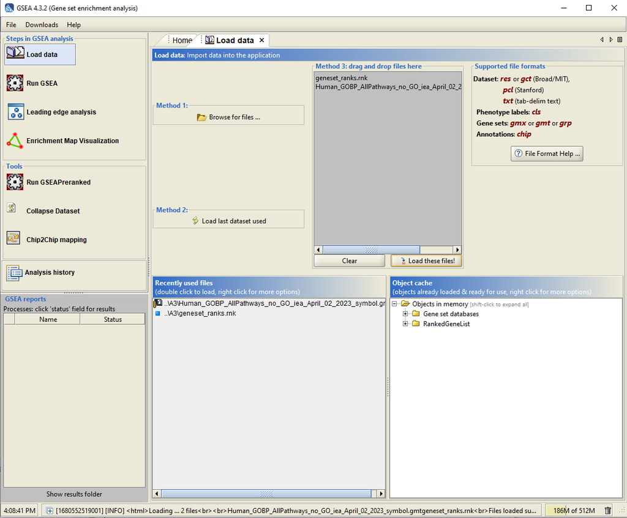

Figure 3. GSEA Load Data

4. Select *Run GSEAPreranked* option from *Tools*.
5. Fix the parameters as follows:
- Gene sets database: `Human_GOBP_AllPathways_no_GO_iea_April_02_2023_symbol.gmt`
- Number of permutations: `1000`
- Ranked List: `geneset_ranks`
- Collapse/Remap to gene symbols: `No_Collapse`
- Max size: exclude large sets: `200`
- Min size: exclude small sets: `15`

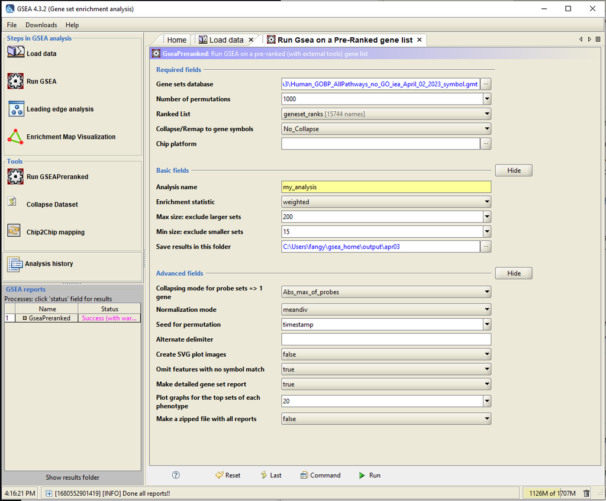

Figure 4. Run GSEAPreranked Analysis

6. Run the analysis.

The analysis status is shown on the bottom left window, and the GSEA report is saved in the default local folder. Since this process is done locally, the TSV version of the GSEA report is uploaded to the `A3_data` folder.

```r
# Read GSEA reports for up-regulated genes
up_report <- read.table(file = "./A3_data/gsea_report_for_na_pos.tsv",
                        sep = '\t',
                        header = TRUE,
                        fill = TRUE)

# Output up-regulated gene report top 10
up_report[1:10, c(1, 4:11)] %>%
  kableExtra::kbl(caption = "Table 5. Up-regulated GSEA Report") %>%
  kableExtra::kable_classic(full_width = F, html_font = "Cambria")
```

Table 5. Up-regulated GSEA Report

| NAME | SIZE | ES | NES | NOM.p.val | FDR.q.val | FWER.p.val | RANK.AT.MAX | LEADING.EDGE |
| --- | --- | --- | --- | --- | --- | --- | --- | --- |
| HALLMARK_INTERFERON_GAMMA_RESPONSE%MSIGDBHALLMARK%HALLMARK_INTERFERON_GAMMA_RESPONSE | 156 | 0.7745812 | 3.113288 | 0 | 0 | 0 | 2010 | tags=62%, list=13%, signal=70% |
| HALLMARK_INTERFERON_ALPHA_RESPONSE%MSIGDBHALLMARK%HALLMARK_INTERFERON_ALPHA_RESPONSE | 78 | 0.8263063 | 3.014483 | 0 | 0 | 0 | 1966 | tags=76%, list=12%, signal=86% |
| INTERFERON ALPHA BETA SIGNALING%REACTOME%R-HSA-909733.7 | 57 | 0.8506919 | 2.998564 | 0 | 0 | 0 | 900 | tags=65%, list=6%, signal=69% |
| INTERFERON SIGNALING%REACTOME DATABASE ID RELEASE 83%913531 | 170 | 0.6771738 | 2.761662 | 0 | 0 | 0 | 1178 | tags=39%, list=7%, signal=42% |
| DEFENSE RESPONSE TO SYMBIONT%GOBP%GO:0140546 | 158 | 0.6653425 | 2.695550 | 0 | 0 | 0 | 1583 | tags=40%, list=10%, signal=44% |
| DEFENSE RESPONSE TO VIRUS%GOBP%GO:0051607 | 158 | 0.6653425 | 2.657509 | 0 | 0 | 0 | 1583 | tags=40%, list=10%, signal=44% |
| MEASLES VIRUS INFECTION%WIKIPATHWAYS_20220510%WP4630%HOMO SAPIENS | 90 | 0.7031283 | 2.631534 | 0 | 0 | 0 | 1956 | tags=44%, list=12%, signal=50% |
| INTERFERON GAMMA SIGNALING%REACTOME%R-HSA-877300.5 | 80 | 0.6837635 | 2.517276 | 0 | 0 | 0 | 1141 | tags=44%, list=7%, signal=47% |
| RESPONSE TO TYPE I INTERFERON%GOBP%GO:0034340 | 30 | 0.8093068 | 2.482111 | 0 | 0 | 0 | 730 | tags=43%, list=5%, signal=45% |
| DE NOVO POST-TRANSLATIONAL PROTEIN FOLDING%GOBP%GO:0051084 | 31 | 0.7948192 | 2.416914 | 0 | 0 | 0 | 632 | tags=29%, list=4%, signal=30% |

```r
# Read GSEA reports for down-regulated genes
down_report <- read.table(file = "./A3_data/gsea_report_for_na_neg.tsv",
                          sep = '\t',
                          header = TRUE,
                          fill = TRUE)

# Output down-regulated gene report top 10
down_report[1:10, c(1, 4:11)] %>%
  kableExtra::kbl(caption = "Table 6. Down-regulated GSEA Report") %>%
  kableExtra::kable_classic(full_width = F, html_font = "Cambria")
```

Table 6. Down-regulated GSEA Report

| NAME | SIZE | ES | NES | NOM.p.val | FDR.q.val | FWER.p.val | RANK.AT.MAX | LEADING.EDGE |
| --- | --- | --- | --- | --- | --- | --- | --- | --- |
| PROTEIN SYNTHESIS: LYSINE%SMPDB%SMP0111874 | 78 | -0.6479284 | -2.216508 | 0 | 0 | 0 | 4420 | tags=73%, list=28%, signal=101% |
| PROTEIN SYNTHESIS: ASPARTIC ACID%SMPDB%SMP0111858 | 78 | -0.6498995 | -2.209499 | 0 | 0 | 0 | 4420 | tags=73%, list=28%, signal=101% |
| PROTEIN SYNTHESIS: ALANINE%PATHWHIZ%PW101384 | 78 | -0.6453942 | -2.208928 | 0 | 0 | 0 | 4420 | tags=73%, list=28%, signal=101% |
| PROTEIN SYNTHESIS: GLUTAMINE%SMPDB%SMP0111862 | 78 | -0.6514974 | -2.202369 | 0 | 0 | 0 | 4420 | tags=74%, list=28%, signal=103% |
| PROTEIN SYNTHESIS: GLUTAMIC ACID%PATHWHIZ%PW112922 | 78 | -0.6514814 | -2.199818 | 0 | 0 | 0 | 4420 | tags=74%, list=28%, signal=103% |
| PROTEIN SYNTHESIS: PROLINE%PATHWHIZ%PW113695 | 78 | -0.6514814 | -2.198124 | 0 | 0 | 0 | 4420 | tags=74%, list=28%, signal=103% |
| PROTEIN SYNTHESIS: ARGININE%SMPDB%SMP0111853 | 78 | -0.6499593 | -2.196775 | 0 | 0 | 0 | 4420 | tags=73%, list=28%, signal=101% |
| PROTEIN SYNTHESIS: THREONINE%PATHWHIZ%PW120525 | 78 | -0.6442015 | -2.194793 | 0 | 0 | 0 | 4420 | tags=73%, list=28%, signal=101% |
| PROTEIN SYNTHESIS: HISTIDINE%PATHWHIZ%PW112929 | 78 | -0.6498874 | -2.192354 | 0 | 0 | 0 | 4420 | tags=73%, list=28%, signal=101% |
| PROTEIN SYNTHESIS: TYROSINE%PATHWHIZ%PW120527 | 78 | -0.6440985 | -2.187529 | 0 | 0 | 0 | 4420 | tags=73%, list=28%, signal=101% |

The top 10 results from up-regulated and down-regulated gene reports are shown above in tables.

## 2.3 GSEA Questions

### Q1. What method did you use? What genesets did you use? Make sure to specify versions and cite your methods.

For the analysis, I used the GSEA pre-ranked algorithm (version 4.3.2) and the human Gene Ontology Biological Processes (GOBP) gene set from the Bader lab (Subramanian et al. 2005). The specific GOBP file I used included all pathways and excluded terms inferred from electronic annotations (IEA) (version April 2nd, 2023). The parameters for the GSEA analysis are described in section 2.2 Run GSEA of the report, and the sample GSEA reports for up-regulated and down-regulated genes can be found in *Tables 5. Up-regulated GSEA Report* and *Tables 6. Down-regulated GSEA Report*.

### Q2. Summarize your enrichment results.

Sample GSEA reports for up-regulated and down-regulated genes can be found in *Tables 5. Up-regulated GSEA Report* and *Tables 6. Down-regulated GSEA Report*.

**Summary for up-regulated genes:**

- 3133 / 5561 gene sets are up-regulated in tumor phenotype
- 1289 gene sets are significant at FDR < 25%
- 660 gene sets are significantly enriched at nominal pvalue < 1%
- 1028 gene sets are significantly enriched at nominal pvalue < 5%

**Summary for down-regulated genes:**

- 2428 / 5561 gene sets are down-regulated in tumor phenotype
- 204 gene sets are significantly enriched at FDR < 25%
- 150 gene sets are significantly enriched at nominal pvalue < 1%
- 342 gene sets are significantly enriched at nominal pvalue < 5%

### Q3. How do these results compare to the results from the thresholded analysis in Assignment #2. Compare qualitatively. Is this a straight forward comparison? Why or why not?

Up-regulated gene set analysis: The GSEA and thresholded analyses both identified a large number of significant up-regulated gene sets, but the specific pathways identified differences between the two methods. The GSEA analysis was dominated by the interferon-related pathway, while the thresholded analysis identified mostly immune response and cytokine signaling pathways. These differences suggest that the two approaches may capture different aspects of the biological response, and combining the results from both analyses may provide a more comprehensive picture of the up-regulated pathways.

Down-regulated gene set analysis: In contrast to the up-regulated gene sets, both GSEA and the thresholded analyses identified relatively few significant down-regulated gene sets. However, the specific pathways identified by each analysis differ. The GSEA analysis identified protein synthesis as significant for down-regulated genes, while the thresholded analysis identified mostly cytoplasmic-related pathways. These differences suggest that the two approaches may capture different aspects of the biological response, and combining the results from both analyses may provide a more comprehensive picture of the down-regulated pathways.

# 3. Visualize Gene Set Enrichment Analysis in Cytoscape

## 3.1 Cytoscape preparation

Cytoscape (version 3.9.1) is used to visualize GSEA, and it requires a descending, na-omitted ranked gene set (Shannon et al. 2003). Therefore, we need to output another specific rank file for Cytoscape.

```r
# Obtain specific rank file for Cytoscape
if (!file.exists("./A3_data/cytoscape_ranks.rnk")) {
    cytoscape_ranks <- data.frame(GeneName = qlf_result$hgnc_symbol,
                                  rank = -log(qlf_result$PValue, base = 10) * sign(qlf_result$logFC))

    # Order from the greatest to smallest
    cytoscape_ranks <- cytoscape_ranks[order(-cytoscape_ranks$rank), ]

    # Remove NA rows
    cytoscape_ranks <- na.omit(cytoscape_ranks)

    # Output .rnk file
    write.table(x = cytoscape_ranks,
                file = file.path("./A3_data", "cytoscape_ranks.rnk"),
                col.names = F,
                row.names = F,
                quote = F,
                sep = "\t")
}
```

## 3.2 Run Cytoscape

### Steps to run Cytoscape locally

1. [Download](https://cytoscape.org/) and open Cytoscape software.
2. Choose *Apps* -> *EnrichmentMap*.
3. Under the Create Enrichment Map window, fix the parameters as follows (others stay default):
- Analysis Type: `GSEA`
- Enrichment Pos: `gsea_report_for_na_pos.tsv`
- Enrichment Neg: `gsea_report_for_na_neg.tsv`
- GMT: `Human_GOBP_AllPathways_no_GO_iea_April_02_2023_symbol.gmt`
- Ranks: `cytoscape_ranks.rnk`
- FDR q-value cutoff: `0.05`
- p-value cutoff: `1.0`

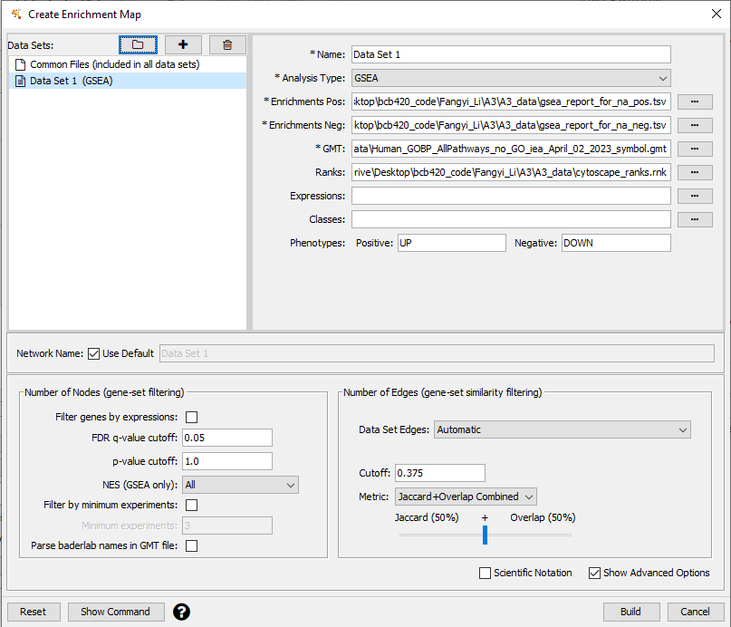

Figure 7. Create Enrichment Map Parameters

4. Build the enrichment Map.

## 3.3 Enrichment Map Analysis and Questions

### Q1. Create an enrichment map - how many nodes and how many edges in the resulting map? What thresholds were used to create this map? Make sure to record all thresholds. Include a screenshot of your network prior to manual layout.

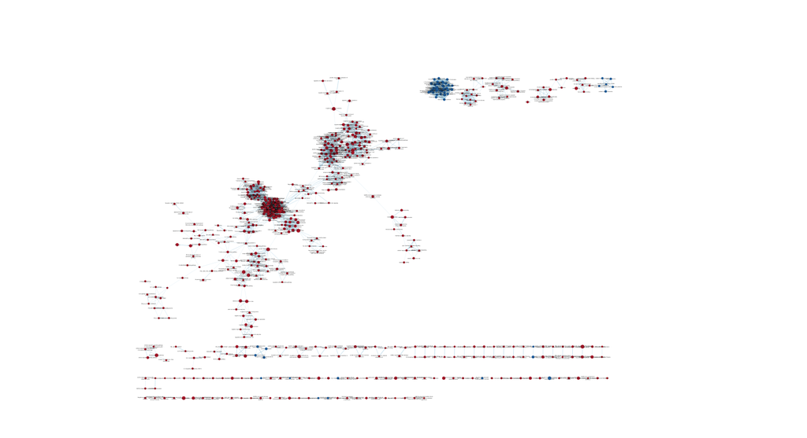

Figure 8. Original Enrichment Map

The EnrichmentMap app (version 3.3.5) is used for building the enrichment map (Merico et al. 2010). There are 617 nodes and 6630 edges in the resulting map. Thresholds I used:

- FDR q-value cutoff (node): `0.05`
- P-value cutoff (node): `1.0`
- Edge cutoff (similarity): `0.375`

### Q2. Annotate your network - what parameters did you use to annotate the network. If you are using the default parameters make sure to list them as well.

The AutoAnnotate app (version 1.4.0) annotates the original enrichment map (Kucera et al. 2016). Parameters used:

- Cluster algorithm: `MCL Cluster`
- Edge weight column: `similarity_coefficient`
- Label column: `GS_DESCR`
- Label algorithm: `WordCloud: Adjacent Words`
- Max words per label: `3`
- Minimum word occurrence: `1`
- Adjacent word bonus: `8`

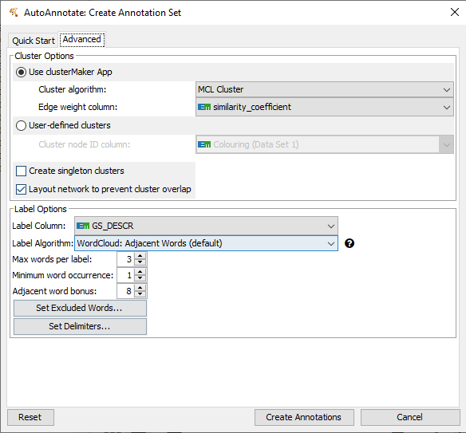

Figure 9. AutoAnnotate Parameters

The result shows that the largest up-regulated cluster is “gli3 proteasome degradation” with 96 nodes, and the largest down-regulated cluster is “selenocysteine synthesis valine” with 40 nodes.

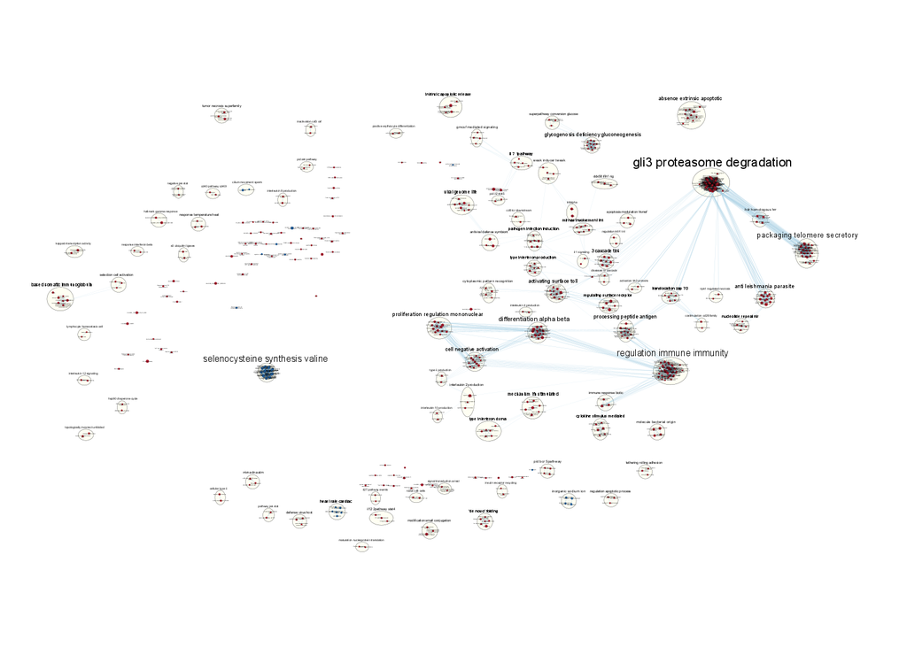

Figure 10. Annotated Enrichment Map

### Q3. Make a publication ready figure - include this figure with proper legends in your notebook.

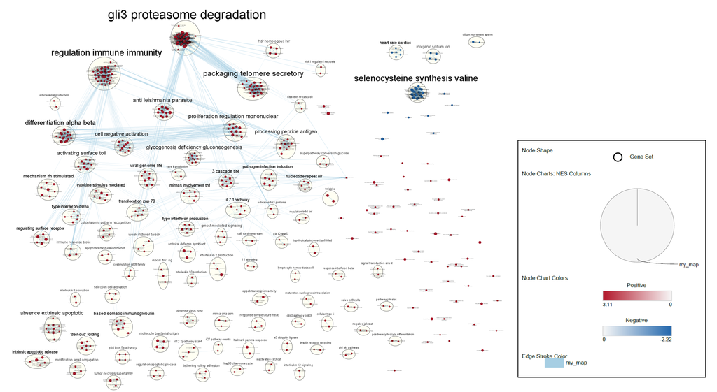

Figure 11. Enrichment Map Publication

### Q4. Collapse your network to a theme network. What are the major themes present in this analysis? Do they fit with the model? Are there any novel pathways or themes?

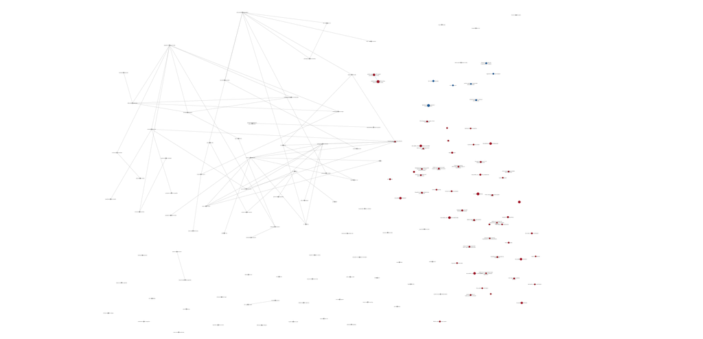

Figure 12. Collapsed Enrichment Map

The major themes are “gli3 proteasome degradation”, “selenocysteine synthesis valine,” “regulatory immune immunity,” “packaging telomere secretory,” “differentiation alpha beta,” etc. Some themes fit the model, and some do not.”Regulatory immune immunity” seems to be the novel theme since regulatory T cells (Tregs) play a critical role in maintaining immune homeostasis and preventing autoimmune diseases. The other pathways listed, including “gli3 proteasome degradation”, “selenocysteine synthesis valine,” “packaging telomere secretory,” and “differentiation alpha beta,” do not appear to be directly related to T cells or the immune system.

# 4. Interpretation and Detailed View of Results

## 4.1 Discussion and Questions

### Q1. Do the enrichment results support conclusions or mechanism discussed in the original paper? How do these results differ from the results you got from Assignment #2 thresholded methods

The original paper reports the upregulation of cytokine and chemokine receptor genes in tumor-resident Treg cells compared to normal tissue resident ones (Plitas et al. 2016). In our up-regulated GSEA analysis, 25 cytokine-related pathways were identified but ranked below the top 100 pathways. However, in the cluster network analysis, the “cytokine stimulus mediated” pathway was up-regulated and ranked 18 in all clusters. Notably, cytokine-related pathways were more significantly enriched in the previous thresholded over-representation analysis conducted by `g:Profiler`. Overall, while the enrichment results partially support the conclusions and mechanisms discussed in the original paper, the differences between the GSEA and thresholded analysis suggest further investigation.

### Q2. Can you find evidence, i.e. publications, to support some of the results that you see. How does this evidence support your result?

The paper, The Role of Cytokines in Breast Cancer Development and Progression, states that “cytokines involved in angiogenesis. The inflammatory infiltrate that is usually found in breast tumors produces IL-6, IL-1α, and IL-1β, which upregulate COX-2, which, in turn, increases VEGF expression in tumor cells promoting angiogenesis.” IL-1α (IL1A) can be found under the upregulated gene list. The paper “suggests that cytokines play an important role in the regulation of both induction and protection in breast cancer (Esquivel-Velázquez et al. 2015).”

The upregulated GSEA analysis suggests a significant association between Type I interferon (IFN-α/β) and Tregs. This finding is supported by a previous study that reports the direct influence of IFN-α/β on the fate of CD4+ and CD8+ T cells during the early stages of antigen recognition, as well as its role as a counter-regulator of T helper type 2 and type 17 responses (Kumar, Connors, and Farber 2018). The enrichment results also indicate that interferon-related pathways rank among the top, further supporting the potential involvement of IFN-α/β in Treg function.

## 4.2 Dark Matter Analysis

**Task**: Sometimes the most interesting information is the gene that has no information. In this type of pathway analysis we can only discover what we have already described previously in the literature or pathway databases. Often pathways found in one disease are applicable to other diseases so this technique can be very helpful. It is important to highlight any genes that are significantly differentially expressed in your model but are not annotated to any pathways. We refer to this set of genes as the dark matter.

```r
# Get the geneset file
capture.output(genesets <- GSA::GSA.read.gmt(dest_gmt_file), file = "gsa_loud.out")
names(genesets$genesets) <- genesets$geneset.names
genes_all_gs <- unique(unlist(genesets$genesets))

# Get the expression data
expression <- normalized_tcell_exp

# Get genes from the set of enriched pathway (no matter what threshold)
all_enr_genesets <- c(up_report$NAME, down_report$NAME)
genes_enr_gs <- c()
for(i in 1:length(all_enr_genesets)){
  current_geneset <- unlist(genesets$genesets[which(genesets$geneset.names %in% all_enr_genesets[i])])
  genes_enr_gs <- union(genes_enr_gs, current_geneset)
}

# Get genes in the significant enrichment results
FDR_threshold <- 0.001
all_enr_genesets_sig <- c(down_report[which(down_report$FDR.q.val < FDR_threshold),]$NAME,
                          up_report[which(up_report$FDR.q.val < FDR_threshold),]$NAME)
genes_enr_gs_sig <- c()
for(i in 1:length(all_enr_genesets_sig)){
  current_geneset <- unlist(genesets$genesets[which(genesets$geneset.names %in% all_enr_genesets_sig[i])])
  genes_enr_gs_sig <- union(genes_enr_gs_sig, current_geneset)
}
```

### Venn Diagram of Dark Matter Overlaps

```r
# Constructe venn diagram
A <- na.omit(genes_all_gs)
B <- na.omit(genes_enr_gs_sig)
C <- expression[, 2]

# Draw venn diagram
png(file.path(getwd(), "A3_figures", "dark_matter_overlaps.png"))
VennDiagram::draw.triple.venn(area1 = length(A), area2 = length(B), area3 = length(C),
                                n12 = length(intersect(A, B)), n13 = length(intersect(A, C)),
                                n23 = length(intersect(B, C)), n123 = length(intersect(A, intersect(B, C))),
                                category = c("all genesets", "all enrichment results", "all expressed data"),
                                fill = c("red", "green", "blue"),
                                cat.col = c("red", "green", "blue"))
```

[output not shown]

[figure not shown]

Figure 13. Venn Diagram of Dark Matter Overlaps

Summary of dark matter analysis:

- There are 15746 unique genes in the expression file.
- There are 2305 unique genes in the enrichment results.
- There are 18526 unique genes in the geneset file.
- There are 3705 genes absent from the GMT file.
- There are 13899 genes absent from the enrichment analysis.

```r
# Get rank file
ranks <- read.table(file.path("A3_data", "geneset_ranks.rnk"), sep = "\t", stringsAsFactors = F)
ranks <- na.omit(ranks)
colnames(ranks) <- c("gene", "rank")

# Get set of genes that have no annotation
genes_no_annotation <- setdiff(C, A)

# Get top ranked genes that have no annotation
ranked_gene_no_annotation <- ranks[which(ranks[,1] %in% genes_no_annotation),]
ranked_gene_no_annotation <- ranked_gene_no_annotation[order(ranked_gene_no_annotation$rank, decreasing = T), ]

ranked_gene_no_annotation [1:10, ] %>%
  kableExtra::kbl(caption = "Table 14. Ranked Gene without Annotation") %>%
  kableExtra::kable_classic(full_width = F, html_font = "Cambria")
```

Table 14. Ranked Gene without Annotation

|  | gene | rank |
| --- | --- | --- |
| 15742 | EML2-AS1 | 6.296782 |
| 15722 | BHLHE40-AS1 | 4.384902 |
| 15708 | LINC00519 | 4.061773 |
| 15704 | IGFL2 | 3.960393 |
| 15696 | LINC01055 | 3.890488 |
| 15694 | KLHDC7B-DT | 3.872217 |
| 15693 | GBP1P1 | 3.834989 |
| 15684 | SNORD14E | 3.752199 |
| 15682 | GTSF1L | 3.732378 |
| 15678 | LINC02416 | 3.666898 |

```r
# Get set of genes that have no enrichment
genes_no_enrichment <- setdiff(C, B)

# Get top ranked genes that have no enrichment
ranked_gene_no_enrichment <- ranks[which(ranks[,1] %in% genes_no_enrichment),]
ranked_gene_no_enrichment <- ranked_gene_no_enrichment[order(ranked_gene_no_enrichment$rank, decreasing = T), ]

ranked_gene_no_enrichment[1:10, ] %>%
  kableExtra::kbl(caption = "Table 15. Ranked Gene without Enrichment") %>%
  kableExtra::kable_classic(full_width = F, html_font = "Cambria")
```

Table 15. Ranked Gene without Enrichment

|  | gene | rank |
| --- | --- | --- |
| 15743 | TYMP | 6.409268 |
| 15742 | EML2-AS1 | 6.296782 |
| 15741 | CREM | 6.009975 |
| 15738 | POLD1 | 5.274515 |
| 15737 | ETV7 | 5.273516 |
| 15734 | FBXW5 | 4.992779 |
| 15733 | ZC3H3 | 4.987251 |
| 15731 | TRIM69 | 4.869366 |
| 15724 | BCL3 | 4.464713 |
| 15723 | PTGIR | 4.440892 |

### Heatmaps

The function `createHeatmap` is defined for generating heatmaps repeatably.

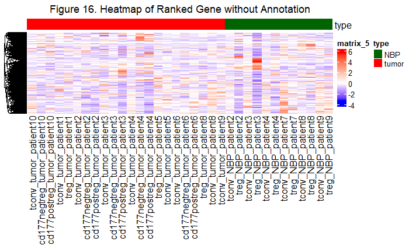

Figure 16. Heatmap of Ranked Gene without Annotation

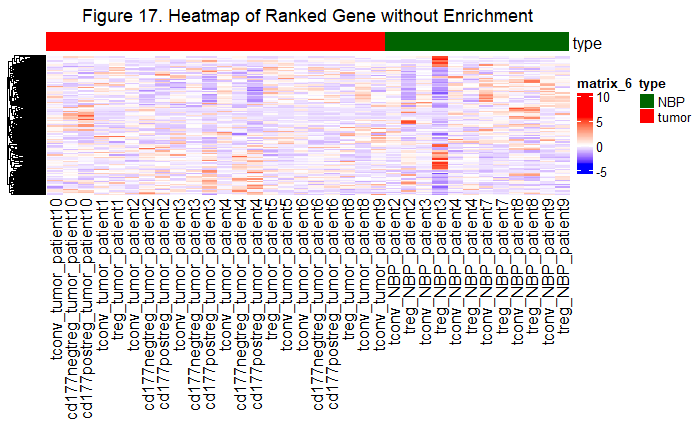

Figure 17. Heatmap of Ranked Gene without Enrichment

```r
# Define a heatmap-creating function
createHeatmap <- function(geneset, my_caption) {
  heatmap_matrix <- normalized_tcell_exp[, 3:ncol(normalized_tcell_exp)]
  rownames(heatmap_matrix) <- normalized_tcell_exp$ensembl_gene_id
  colnames(heatmap_matrix) <- colnames(normalized_tcell_exp[, 3:ncol(normalized_tcell_exp)])

  # Scale
  heatmap_matrix <- t(scale(t(heatmap_matrix)))
  rownames(heatmap_matrix) <- normalized_tcell_exp$hgnc_symbol

  # Create top hit version of heatmap matrix
  heatmap_matrix_tophits <- heatmap_matrix[which(rownames(heatmap_matrix) %in% geneset),]
  heatmap_matrix_tophits <- heatmap_matrix_tophits[, c(grep("tumor", colnames(heatmap_matrix_tophits)),
                            grep("NBP", colnames(heatmap_matrix_tophits)))]

  # Decide the colour by range
  heatmap_col = circlize::colorRamp2(c(min(heatmap_matrix_tophits),
                                     0,
                                     max(heatmap_matrix_tophits)),
                                     c("blue", "white", "red"))

  # Set colours
  ha_colours <- c("red", "darkgreen")
  names(ha_colours) <- c("tumor", "NBP")

  # Set annotations
  ha <- ComplexHeatmap::HeatmapAnnotation(df = data.frame(type = rep(c("tumor", "NBP"), c(22, 12))),
                                          col = list(type = ha_colours))

  # Plot annotated heatmap
  heatmap_result <- ComplexHeatmap::Heatmap(as.matrix(heatmap_matrix_tophits),
                           cluster_rows = TRUE,
                           cluster_columns = FALSE,
                           show_row_dend = TRUE,
                           show_column_dend = FALSE,
                           col = heatmap_col,
                           show_column_names = TRUE,
                           show_row_names = FALSE,
                           show_heatmap_legend = TRUE,
                           top_annotation = ha,
                           column_title = my_caption)

    return(heatmap_result)
}


hm_no_annotation <- createHeatmap(ranked_gene_no_annotation$gene, "Figure 16. Heatmap of Ranked Gene without Annotation")
hm_no_enrichment <- createHeatmap(ranked_gene_no_enrichment$gene, "Figure 17. Heatmap of Ranked Gene without Enrichment")

# Heatmaps below are pre-generated since it takes too long to run and load the images.
```

Both heatmaps above do not show any distinct clustering of genes among the NBP and tumor samples. Hence, it is reasonable to conclude that the dark matter component of the data is random and has a limited impact on the enrichment analysis.

# References

Chen, Hanbo. 2022. *VennDiagram: Generate High-Resolution Venn and Euler Plots*.

Chen, Yunshun, Aaron A T Lun, and Gordon K Smyth. 2016. “From Reads to Genes to Pathways: Differential Expression Analysis of RNA-Seq Experiments Using Rsubread and the edgeR Quasi-Likelihood Pipeline.” *F1000Research* 5: 1438. https://doi.org/10.12688/f1000research.8987.2.

Chen, Yunshun, Aaron TL Lun, Davis J McCarthy, Matthew E Ritchie, Belinda Phipson, Yifang Hu, Xiaobei Zhou, Mark D Robinson, and Gordon K Smyth. 2022. *edgeR: Empirical Analysis of Digital Gene Expression Data in r*.

Davis, Sean. 2022. *GEOquery: Get Data from NCBI Gene Expression Omnibus (GEO)*.

Davis, Sean, and Paul Meltzer. 2007. “GEOquery: A Bridge Between the Gene Expression Omnibus (GEO) and BioConductor.” *Bioinformatics* 14: 1846–47.

Durinck, Steffen, and Wolfgang Huber. 2022. *biomaRt: Interface to BioMart Databases (i.e. Ensembl)*.

Durinck, Steffen, Yves Moreau, Arek Kasprzyk, Sean Davis, Bart De Moor, Alvis Brazma, and Wolfgang Huber. 2005. “BioMart and Bioconductor: A Powerful Link Between Biological Databases and Microarray Data Analysis.” *Bioinformatics* 21: 3439–40.

Durinck, Steffen, Paul T. Spellman, Ewan Birney, and Wolfgang Huber. 2009. “Mapping Identifiers for the Integration of Genomic Datasets with the r/Bioconductor Package biomaRt.” *Nature Protocols* 4: 1184–91.

Efron, Brad, and R. Tibshirani. 2022. *GSA: Gene Set Analysis*. http://www-stat.stanford.edu/~tibs/GSA.

Esquivel-Velázquez, Marcela, Pedro Ostoa-Saloma, Margarita Isabel Palacios-Arreola, Karen E Nava-Castro, Julieta Ivonne Castro, and Jorge Morales-Montor. 2015. “The Role of Cytokines in Breast Cancer Development and Progression.” *Journal of Interferon & Cytokine Research* 35 (1): 1–16.

Gentleman, R., V. Carey, M. Morgan, and S. Falcon. 2022. *Biobase: Base Functions for Bioconductor*. https://bioconductor.org/packages/Biobase.

Gu, Zuguang. 2022a. *Circlize: Circular Visualization*. https://CRAN.R-project.org/package=circlize.

———. 2022b. “Complex Heatmap Visualization.” *iMeta*. https://doi.org/10.1002/imt2.43.

———. 2022c. *ComplexHeatmap: Make Complex Heatmaps*.

Gu, Zuguang, Roland Eils, and Matthias Schlesner. 2016. “Complex Heatmaps Reveal Patterns and Correlations in Multidimensional Genomic Data.” *Bioinformatics*. https://doi.org/10.1093/bioinformatics/btw313.

Gu, Zuguang, Lei Gu, Roland Eils, Matthias Schlesner, and Benedikt Brors. 2014. “Circlize Implements and Enhances Circular Visualization in r.” *Bioinformatics* 30: 2811–12.

Huber, W., V. J. Carey, R. Gentleman, S. Anders, M. Carlson, B. S. Carvalho, H. C. Bravo, et al. 2015a. “Orchestrating High-Throughput Genomic Analysis with Bioconductor.” *Nature Methods* 12 (2): 115–21. http://www.nature.com/nmeth/journal/v12/n2/full/nmeth.3252.html.

Huber, W., Carey, V. J., Gentleman, R., Anders, et al. 2015b. “Orchestrating High-Throughput Genomic Analysis with Bioconductor.” *Nature Methods* 12 (2): 115–21. http://www.nature.com/nmeth/journal/v12/n2/full/nmeth.3252.html.

Isserlin, Ruth. 2023a. “BCB420 Lecture 1 Notes about Docker.” https://q.utoronto.ca/courses/294979/files/24086816?module_item_id=4315655.

———. 2023b. “BCB420 Lecture 10 Notes about GSEA.” https://q.utoronto.ca/courses/294979/files/24035531?module_item_id=4287872.

———. 2023c. “BCB420 Lecture 11 Notes about EM and Other Apps.” https://q.utoronto.ca/courses/294979/files/24035526?module_item_id=4287888.

———. 2023d. “BCB420 Lecture 12 Notes about EM.” https://q.utoronto.ca/courses/294979/files/24035559?module_item_id=4287901.

———. 2023e. “BCB420 Lecture 3 Notes about Expression Data.” https://q.utoronto.ca/courses/294979/files/24593564?module_item_id=4468602&fd_cookie_set=1.

———. 2023f. “BCB420 Lecture 4 Notes about Normalization.” https://q.utoronto.ca/courses/294979/files/24035536?module_item_id=4287827.

———. 2023g. “BCB420 Lecture 5 Notes about Identifier Mapping.” https://q.utoronto.ca/courses/294979/files/24035540?module_item_id=4287835.

———. 2023h. “BCB420 Lecture 6 Notes about Differential Expression.” https://q.utoronto.ca/courses/294979/files/24035542?module_item_id=4287844.

———. 2023i. “BCB420 Lecture 7 Notes about Annotations and ORA.” https://q.utoronto.ca/courses/294979/files/24035552?module_item_id=4287853.

———. 2023j. “BCB420 Lecture 7 Notes about RMarkdown.” https://q.utoronto.ca/courses/294979/files/24035549?module_item_id=4448907.

Kolberg, Liis, and Uku Raudvere. 2021. *Gprofiler2: Interface to the g:profiler Toolset*. https://CRAN.R-project.org/package=gprofiler2.

Kucera, Mike, Ruth Isserlin, Arkady Arkhangorodsky, and Gary D Bader. 2016. “AutoAnnotate: A Cytoscape App for Summarizing Networks with Semantic Annotations.” *F1000Research* 5 (1717): 1717.

Kumar, Brahma V, Thomas J Connors, and Donna L Farber. 2018. “Human t Cell Development, Localization, and Function Throughout Life.” *Immunity* 48 (2): 202–13.

McCarthy, Davis J, Yunshun Chen, and Gordon K Smyth. 2012. “Differential Expression Analysis of Multifactor RNA-Seq Experiments with Respect to Biological Variation.” *Nucleic Acids Research* 40 (10): 4288–97. https://doi.org/10.1093/nar/gks042.

Merico, Daniele, Ruth Isserlin, Oliver Stueker, Andrew Emili, and Gary D Bader. 2010. “Enrichment Map: A Network-Based Method for Gene-Set Enrichment Visualization and Interpretation.” *PloS One* 5 (11): e13984.

Mootha, Vamsi K, Cecilia M Lindgren, Karl-Fredrik Eriksson, Aravind Subramanian, Smita Sihag, Joseph Lehar, Pere Puigserver, et al. 2003. “PGC-1$\alpha$-Responsive Genes Involved in Oxidative Phosphorylation Are Coordinately Downregulated in Human Diabetes.” *Nature Genetics* 34 (3): 267–73.

Morgan, Martin. 2022. *BiocManager: Access the Bioconductor Project Package Repository*. https://CRAN.R-project.org/package=BiocManager.

Müller, Kirill, Hadley Wickham, David A. James, and Seth Falcon. 2022. *RSQLite: SQLite Interface for r*. https://CRAN.R-project.org/package=RSQLite.

Plitas, George, Catherine Konopacki, Kenmin Wu, Paula D Bos, Monica Morrow, Ekaterina V Putintseva, Dmitriy M Chudakov, and Alexander Y Rudensky. 2016. “Regulatory t Cells Exhibit Distinct Features in Human Breast Cancer.” *Immunity* 45 (5): 1122–34.

R Core Team. 2022. *R: A Language and Environment for Statistical Computing*. Vienna, Austria: R Foundation for Statistical Computing. https://www.R-project.org/.

R Special Interest Group on Databases (R-SIG-DB), Hadley Wickham, and Kirill Müller. 2022. *DBI: R Database Interface*. https://CRAN.R-project.org/package=DBI.

Ritchie, Matthew E, Belinda Phipson, Di Wu, Yifang Hu, Charity W Law, Wei Shi, and Gordon K Smyth. 2015. “limma Powers Differential Expression Analyses for RNA-Sequencing and Microarray Studies.” *Nucleic Acids Research* 43 (7): e47. https://doi.org/10.1093/nar/gkv007.

Robinson, Mark D, Davis J McCarthy, and Gordon K Smyth. 2010. “edgeR: A Bioconductor Package for Differential Expression Analysis of Digital Gene Expression Data.” *Bioinformatics* 26 (1): 139–40. https://doi.org/10.1093/bioinformatics/btp616.

Rowe, Brian Lee Yung. 2016. *Futile.logger: A Logging Utility for r*. https://CRAN.R-project.org/package=futile.logger.

Shannon, Paul, Andrew Markiel, Owen Ozier, Nitin S Baliga, Jonathan T Wang, Daniel Ramage, Nada Amin, Benno Schwikowski, and Trey Ideker. 2003. “Cytoscape: A Software Environment for Integrated Models of Biomolecular Interaction Networks.” *Genome Research* 13 (11): 2498–2504.

Smyth, Gordon, Yifang Hu, Matthew Ritchie, Jeremy Silver, James Wettenhall, Davis McCarthy, Di Wu, et al. 2022. *Limma: Linear Models for Microarray Data*. http://bioinf.wehi.edu.au/limma.

Subramanian, Aravind, Pablo Tamayo, Vamsi K Mootha, Sayan Mukherjee, Benjamin L Ebert, Michael A Gillette, Amanda Paulovich, et al. 2005. “Gene Set Enrichment Analysis: A Knowledge-Based Approach for Interpreting Genome-Wide Expression Profiles.” *Proceedings of the National Academy of Sciences* 102 (43): 15545–50.

Team, The Bioconductor Dev. 2022. *BiocGenerics: S4 Generic Functions Used in Bioconductor*. https://bioconductor.org/packages/BiocGenerics.

Temple Lang, Duncan. 2022. *RCurl: General Network (HTTP/FTP/...) Client Interface for r*. https://CRAN.R-project.org/package=RCurl.

Xie, Yihui. 2014. “Knitr: A Comprehensive Tool for Reproducible Research in R.” In *Implementing Reproducible Computational Research*, edited by Victoria Stodden, Friedrich Leisch, and Roger D. Peng. Chapman; Hall/CRC. http://www.crcpress.com/product/isbn/9781466561595.

———. 2015. *Dynamic Documents with R and Knitr*. 2nd ed. Boca Raton, Florida: Chapman; Hall/CRC. https://yihui.org/knitr/.

———. 2022. *Knitr: A General-Purpose Package for Dynamic Report Generation in r*. https://yihui.org/knitr/.

Zhu, Hao. 2021. *kableExtra: Construct Complex Table with Kable and Pipe Syntax*. https://CRAN.R-project.org/package=kableExtra.

Zhu, Jack, and Sean Davis. 2022. *GEOmetadb: A Compilation of Metadata from NCBI GEO*.

Zhu, Yuelin, Sean Davis, Robert Stephens, Paul S. Meltzer, and Yidong Chen. 2008. “GEOmetadb: Powerful Alternative Search Engine for the Gene Expression Omnibus.” *Bioinformatics (Oxford, England)* 24 (23): 2798–2800. https://doi.org/10.1093/bioinformatics/btn520.